# 1B project example analysis

# Step 6: Filter

This example filters sex to only include binary gender and also provides the code for how to create a new variable for employment.

```r
anxiety_filter <- anxiety_dat %>%
  filter(user_sex %in% c("male", "female")) %>%
  mutate(employed = (employment > 0))
```

# Step 7: Sub-scale scores

```r
dat_means <- anxiety_filter %>% #
  pivot_longer(names_to = "var", values_to = "val", anxiety_1:anxiety_5) %>%
  group_by_at(vars(-val, -var)) %>%
  summarise(anxiety_mean = mean(val, na.rm = TRUE)) %>%
  ungroup()
```

# Step 8: Split the dataset

```r
dat_means_team <- dat_means %>%
  filter(team == 7)
```

# Step 9: Demographic information

This example shows how to do the code for the overall dataset. You also need to repeat this code but using your team dataset.

```r
# count the total number of participants in the dataset

dat_means %>%
  count()

# count the number of responses to each level of user_sex (for gender)
dat_means %>%
  group_by(user_sex) %>%
  count()

# count the number of responses to each level of mature student status (you may need to change this variable to the one you're using)
dat_means %>%
  group_by(mature) %>%
  count()

# count the number of responses across two categories (you might not need or want to do this)
dat_means %>%
  group_by(user_sex,mature) %>%
  count()
```

[output not shown]

Once you’ve done this you might realise that you have participants in the dataset that shouldn’t be there. For example, you might have people who have answered “Not applicable” to the mature student question, or you might have some NAs (missing data from when people didn’t respond).

You need to think about whether you need to get rid of any observations from your dataset. For example, if you’re looking at gender differences, then you can’t have people who are missing gender information. You may have said in your pre-reg that you would only include non-binary people if they made up a certain proportion of the data. If you’re looking at mature student status, you can’t have people who didn’t answer the question or who said not applicable (i.e., postgraduate students). You need to decide whether any of this is a problem, and potentially go back and add in an extra filter to step 6.

```r
dat_means %>%
  summarise(mean_age = mean(user_age, na.rm = TRUE),
            sd_age = sd(user_age, na.rm = TRUE))
```

```
## # A tibble: 1 x 2
##   mean_age sd_age
##      <dbl>  <dbl>
## 1     57.2   269.
```

```r
dat_means_team %>%
  summarise(mean_age = mean(user_age, na.rm = TRUE),
            sd_age = sd(user_age, na.rm = TRUE))
```

```
## # A tibble: 1 x 2
##   mean_age sd_age
##      <dbl>  <dbl>
## 1     23.3   8.89
```

# Step 10: Descriptive statistics

Use summarise and group_by to calculate the mean, median, and standard deviation of the sub-scale scores for each group. Do this separately for the full dataset and your team dataset.

```r
dat_means %>%
  group_by(mature) %>%
  summarise(mean = mean(anxiety_mean, na.rm = TRUE),
            median = median(anxiety_mean,na.rm = TRUE),
            sd = sd(anxiety_mean, na.rm = TRUE))
```

```
## # A tibble: 4 x 4
##   mature  mean median    sd
##   <fct>  <dbl>  <dbl> <dbl>
## 1 1       4.45    4.6  1.65
## 2 2       4.68    4.8  1.37
## 3 3       4.73    4.6  1.32
## 4 NULL    4.17    4.2  1.48
```

```r
dat_means_team %>%
  group_by(mature) %>%
  summarise(mean = mean(anxiety_mean, na.rm = TRUE),
            median = median(anxiety_mean, na.rm = TRUE),
            sd = sd(anxiety_mean,na.rm = TRUE))
```

```
## # A tibble: 3 x 4
##   mature  mean median    sd
##   <fct>  <dbl>  <dbl> <dbl>
## 1 1       4.17   4.8   2.41
## 2 2       5.10   4.8   1.35
## 3 3       4.32   4.15  1.20
```

# Step 11: Visualisation

You now need to create a bar chart with error bars, a violin-boxplot and a grouped density plot for both the full dataset and your team dataset. You’ve done all of these before, just find a previous example code and change the variables and axis labels.

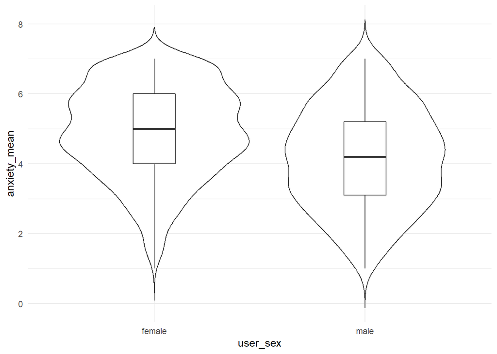

```r
ggplot(dat_means, aes(x = user_sex, y = anxiety_mean)) +
  geom_violin(trim = FALSE) +
  geom_boxplot(width = .2) +
  theme_minimal()
```

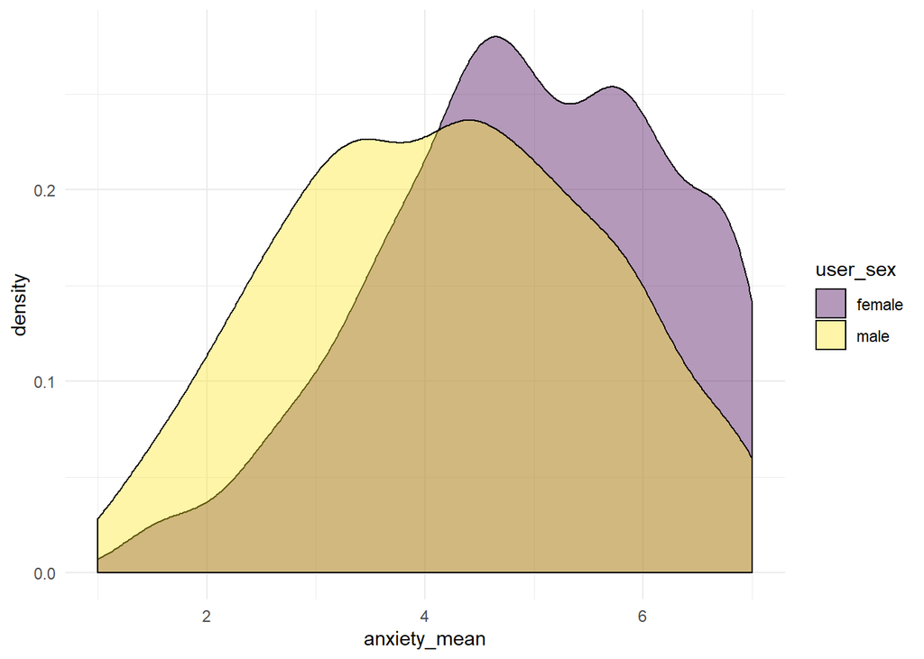

```r
ggplot(dat_means, aes(x = anxiety_mean, fill = user_sex)) +
  geom_density(alpha = .4) +
  scale_fill_viridis_d() +
  theme_minimal()
```

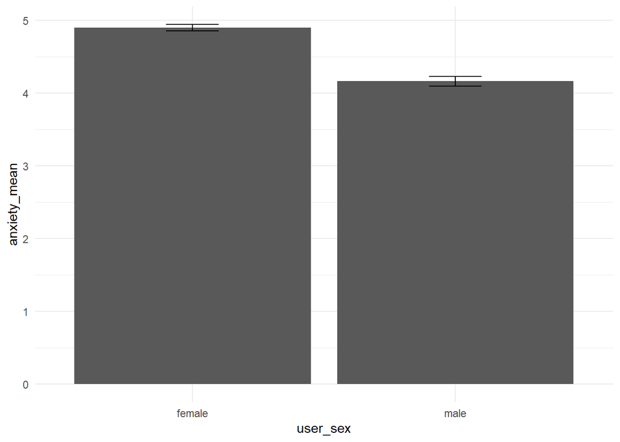

```r
dat_means %>%
  ggplot(aes(x = user_sex, y = anxiety_mean)) +
  stat_summary(geom = "bar", fun.y = "mean") +
  stat_summary(geom = "errorbar", fun.data = "mean_se", width = .2) +
  theme_minimal()
```

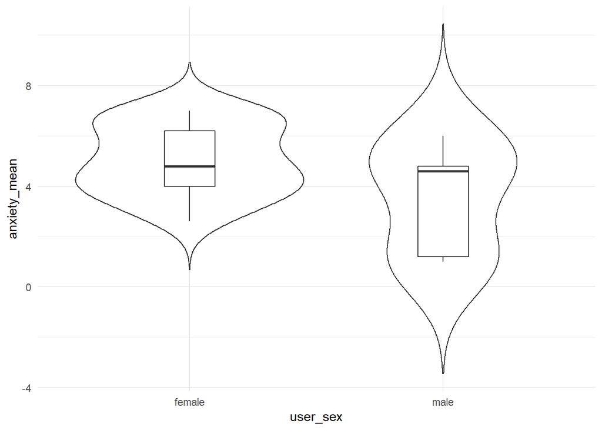

```r
ggplot(dat_means_team, aes(x = user_sex, y = anxiety_mean)) +
  geom_violin(trim = FALSE) +
  geom_boxplot(width = .2) +
  theme_minimal()
```

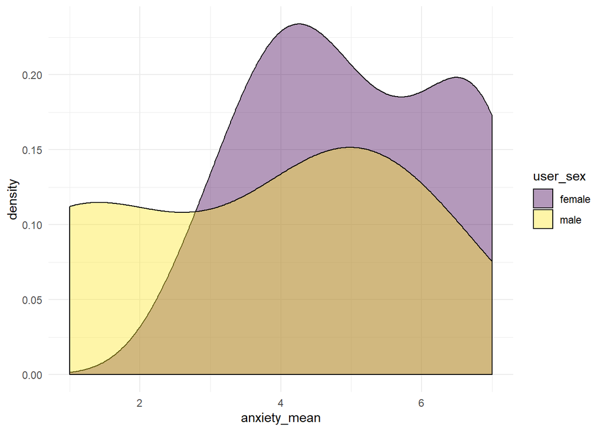

```r
ggplot(dat_means_team, aes(x = anxiety_mean, fill = user_sex)) +
  geom_density(alpha = .4) +
  scale_fill_viridis_d() +
  theme_minimal()
```

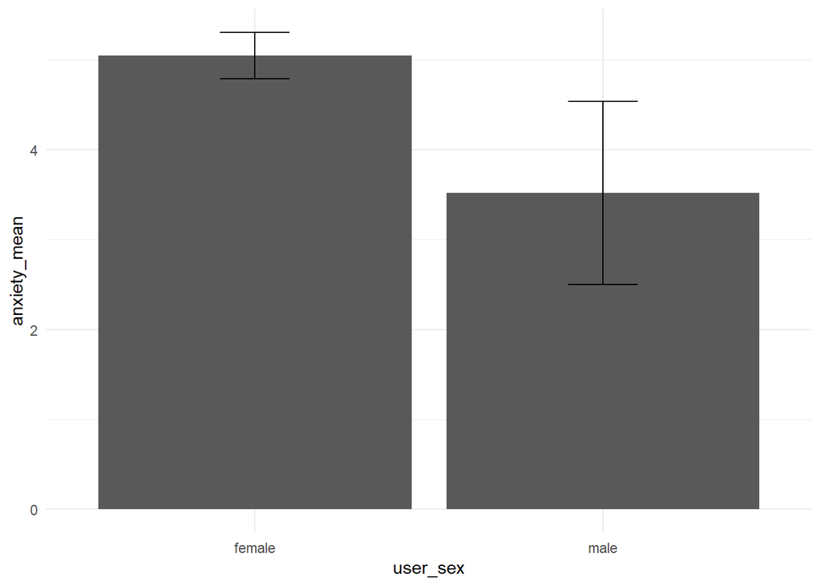

```r
dat_means_team %>%
  ggplot(aes(x = user_sex, y = anxiety_mean)) +
  stat_summary(geom = "bar", fun.y = "mean") +
  stat_summary(geom = "errorbar", fun.data = "mean_se", width = .2) +
  theme_minimal()
```

# Step 12: Statistical analysis

In this step I am going to show you how to conduct a statistical analysis known as a t-test so that you can see whether your intuition from the descriptive statistics plays out and your results are statistically significant or not.

To help you understand how to interpret the results, first I’d suggest you recap the [Statistical Thinking](https://nobaproject.com/modules/statistical-thinking) chapter and you can also read in more detail about what [a t-test is here](https://www.statisticshowto.datasciencecentral.com/probability-and-statistics/t-test/).

The key thing that you need to know for your analysis is that t-tests compare the means of **two groups**.

The first thing you need to do is to check how many groups R thinks your independent variable has. Whilst you may only have data from e.g., men and women left in your dataset, the underlying structure of the data might still involve non-binary people or people who didn’t answer.

First, run `summary()` on the dataset that contains the mean sub-scale score for each participant. You can see from the output below that R thinks that `user_sex` has four levels (male, female, na, nonbinary) even those there’s no data for two of those levels. For the variable mature, we’re only interested in those who answered 1 or 2, but there’s still data for 3 and NULL. For employed, there’s only two values, TRUE and FALSE and then there’s a few missing data points.

This is an important lesson to remember - there’s a difference between the data you can see and the **structure** of the data.

```r
summary(dat_means)
```

```
##     user_id           user_sex      user_age           team
##  Min.   :15917   female   :971   Min.   :  15.00   Length:1473
##  1st Qu.:24404   male     :502   1st Qu.:  18.00   Class :character
##  Median :25972   na       :  0   Median :  19.00   Mode  :character
##  Mean   :25839   nonbinary:  0   Mean   :  57.19
##  3rd Qu.:27084                   3rd Qu.:  20.00
##  Max.   :28972                   Max.   :2020.10
##                                  NA's   :2
##   mature       employment      employed        anxiety_mean
##  1   : 172   Min.   : 0.000   Mode :logical   Min.   :1.000
##  2   :1157   1st Qu.: 0.000   FALSE:825       1st Qu.:3.600
##  3   : 127   Median : 0.000   TRUE :639       Median :4.600
##  NULL:  17   Mean   : 6.149   NA's :9         Mean   :4.648
##              3rd Qu.:12.000                   3rd Qu.:5.800
##              Max.   :60.000                   Max.   :7.000
##              NA's   :9                        NA's   :4
```

I’m going to give you three examples to show how you can run t-tests on each of these variables.

## Example 1

This is the easiest example because our grouping variable employment already only has two conditions.

The code for the t-test has two obligatory arguments.

- `formula` is the design of the study. This takes the form `dv ~ iv` or `score by group`
- `data` is the data you want to use. This should be the dataset you used to create the graphs. I’d recommend just using the full dataset rather than your team’s data because of the small sample sizes.

```r
t.test(formula = anxiety_mean ~ employed, data = dat_means)
```

```
##
##  Welch Two Sample t-test
##
## data:  anxiety_mean by employed
## t = -1.6423, df = 1311.3, p-value = 0.1008
## alternative hypothesis: true difference in means is not equal to 0
## 95 percent confidence interval:
##  -0.26977096  0.02390915
## sample estimates:
## mean in group FALSE  mean in group TRUE
##            4.593317            4.716248
```

In the above output, look for the p-value. If this is below .05 then this means there is less than a 5% probability that you would observe these results under the null hypothesis so you would conclude that there is a statistically significant difference in the means. In this example, the p-value is 0.10, which means there is a 10% probability of observing this score under the null hypothesis and so we conclude there is no statistically significant difference in test anxiety scores between those who are employed and those who aren’t.

## Example 2

For the second example we will use gender, which only has data remaining for two conditions but the underlying structure still represents 4 levels. R is clever enough to figure out that even though there are 4 levels, it should only compare the data for those groups where there are observations.

```r
t.test(formula = anxiety_mean ~ user_sex, data = dat_means)
```

```
##
##  Welch Two Sample t-test
##
## data:  anxiety_mean by user_sex
## t = 9.5496, df = 933.8, p-value < 2.2e-16
## alternative hypothesis: true difference in means is not equal to 0
## 95 percent confidence interval:
##  0.5850850 0.8877645
## sample estimates:
## mean in group female   mean in group male
##             4.898282             4.161857
```

In the above output, you can see that the p-value looks a bit strange `p-value < 2.2e-16`. This is because R is using **scientific notation**. The `e-16` bit means move the decimal point 16 places to the left, i.e., the p-value is actually 0.00000000000000022 and therefore we can conclude that we would be very unlikely to observe this result under the null hypothesis and we have found a significant difference, with women having higher anxiety scores than men (although please remember what you learned about probability, improbable is not impossible and false positive are very real).

## Example 3

The final example is a little bit trickier because we want to compare traditional and mature students, however, the dataset also has data from those who indicated this was not applicable (postgraduate) as well as missing data.

If you were to run the below code, you’d get an error that says `Error in t.test.formula(formula = anxiety_mean ~ mature, data = dat_means) : grouping factor must have exactly 2 levels`. What this means is that a t-test can only compare two groups, and you’ve given R a grouping variable that has data from more than two groups, so R doesn’t know what to do and doesn’t want to guess.

```r
t.test(formula = anxiety_mean ~ mature, data = dat_means)
```

Instead, we must tell R which data to select. There are a couple of different ways you can do this, but I find using tidyverse functions and the pipes easiest.

You can read the below as “take the data in dat_means, then just select conditions 1 and 2 from the mature group, then run a t-test that compares these two groups”. In this case, the p-value is .09 so there is no statistically significant difference between mature and traditional student’s reported anxiety.

To be completely honest, I am not entirely sure what the `data = .` argument means, I think it’s something to do with using the pipes. What I know for sure is that this work won’t unless you specify this argument so make sure it’s in there.

```r
dat_means %>%
  filter(mature %in% c(1,2)) %>%
  t.test(formula = anxiety_mean ~ mature, data = .)
```

```
##
##  Welch Two Sample t-test
##
## data:  anxiety_mean by mature
## t = -1.681, df = 207.55, p-value = 0.09427
## alternative hypothesis: true difference in means is not equal to 0
## 95 percent confidence interval:
##  -0.4837099  0.0384686
## sample estimates:
## mean in group 1 mean in group 2
##        4.452907        4.675528
```

Finally, if you want to compare multiple different groups, you could use filter to select e.g., male and female, then male and non-binary, then female and non-binary and run separate tests. To prevent inflating the false-positive rate, if you run multiple tests you should multiple the p-value by the number of tests. E.g., if your p-value is .03 and you ran three tests, you should consider this as a p-value of .09. This is known as the Bonferroni correction and there is [more info here](https://en.wikipedia.org/wiki/Multiple_comparisons_problem).